# Soluciones 5

Sergio Camiz

2025-05-21

## 1 Construir una carpeta Ejercicio 5

*Hecho*

*Se define también la función que incluye los intervalos de confianza en el summary de los modelos.*

## 2 Cargar desde Paideia:

```
  Linnerud.csv
  Decathlon.csv
```

```r
lin                 <- read.csv("Linnerud.csv",row.names=1)
dec                 <- read.csv("Decathlon.csv",row.names=1)
```

```
y colocarlos en Rstudio como siempre
```

## 3 En Rstudio instalar

car, leaps y faraway (install.package(“car”, ……)

```r
library(car)
library(leaps)
library(faraway)
```

## 4 Con Linnerud,

hacer el modelo Squats~Weight+Waist+Pulse tal cual

```r
lin1                <- lm(Squats~Weight+Waist+Pulse,data=lin)
sum.lm(lin1)
```

```
##
## Call:
## lm(formula = Squats ~ Weight + Waist + Pulse, data = lin)
##
## Residuals:
##    Min     1Q Median     3Q    Max
## -74.19 -36.68 -12.41  40.28  81.64
##
## Coefficients:
##                           2.5 %    97.5 % Std. Error t value Pr(>|t|)
## (Intercept)  623.2817  199.5100 1047.0535   199.9013   3.118  0.00663 **
## Weight         0.7277   -1.3356    2.7909     0.9733   0.748  0.46552
## Waist        -17.3872  -33.2127   -1.5617     7.4652  -2.329  0.03328 *
## Pulse          0.1393   -3.5805    3.8591     1.7547   0.079  0.93770
## ---
## Signif. codes:  0 '***' 0.001 '**' 0.01 '*' 0.05 '.' 0.1 ' ' 1
##
## Residual standard error: 51.18 on 16 degrees of freedom
## Multiple R-squared:  0.4365, Adjusted R-squared:  0.3308
## F-statistic: 4.131 on 3 and 16 DF,  p-value: 0.02394
```

```r
anova(lin1)
```

```
## Analysis of Variance Table
##
## Response: Squats
##           Df Sum Sq Mean Sq F value  Pr(>F)
## Weight     1  18083 18083.4  6.9034 0.01829 *
## Waist      1  14365 14365.1  5.4839 0.03246 *
## Pulse      1     17    16.5  0.0063 0.93770
## Residuals 16  41912  2619.5
## ---
## Signif. codes:  0 '***' 0.001 '**' 0.01 '*' 0.05 '.' 0.1 ' ' 1
```

```r
vcov(lin1)
```

```
##             (Intercept)     Weight        Waist        Pulse
## (Intercept) 39960.51033 37.5347218 -923.8114108 -246.5296386
## Weight         37.53472  0.9472596   -6.1838465    0.2173418
## Waist        -923.81141 -6.1838465   55.7289757    0.9882471
## Pulse        -246.52964  0.2173418    0.9882471    3.0789385
```

o luego haber centrado los regresores y las dos tablas ANOVA:

```r
linc                <- as.data.frame(scale(lin,scale=FALSE))
apply(linc,2,mean)
```

```
##        Weight         Waist         Pulse         Pulls        Squats         Jumps
##  5.685036e-15  1.421064e-15 -1.421172e-15  7.106728e-16 -1.137059e-14  2.132062e-15
```

```r
linc$Squats         <- lin$Squats
lin2                <- lm(Squats~Weight+Waist+Pulse,data=as.data.frame(linc))
sum.lm(lin2)
```

```
##
## Call:
## lm(formula = Squats ~ Weight + Waist + Pulse, data = as.data.frame(linc))
##
## Residuals:
##    Min     1Q Median     3Q    Max
## -74.19 -36.68 -12.41  40.28  81.64
##
## Coefficients:
##                         2.5 %   97.5 % Std. Error t value Pr(>|t|)
## (Intercept) 145.5500 121.2889 169.8111    11.4444  12.718 8.83e-10 ***
## Weight        0.7277  -1.3356   2.7909     0.9733   0.748   0.4655
## Waist       -17.3872 -33.2127  -1.5617     7.4652  -2.329   0.0333 *
## Pulse         0.1393  -3.5805   3.8591     1.7547   0.079   0.9377
## ---
## Signif. codes:  0 '***' 0.001 '**' 0.01 '*' 0.05 '.' 0.1 ' ' 1
##
## Residual standard error: 51.18 on 16 degrees of freedom
## Multiple R-squared:  0.4365, Adjusted R-squared:  0.3308
## F-statistic: 4.131 on 3 and 16 DF,  p-value: 0.02394
```

```r
anova(lin2)
```

```
## Analysis of Variance Table
##
## Response: Squats
##           Df Sum Sq Mean Sq F value  Pr(>F)
## Weight     1  18083 18083.4  6.9034 0.01829 *
## Waist      1  14365 14365.1  5.4839 0.03246 *
## Pulse      1     17    16.5  0.0063 0.93770
## Residuals 16  41912  2619.5
## ---
## Signif. codes:  0 '***' 0.001 '**' 0.01 '*' 0.05 '.' 0.1 ' ' 1
```

```r
vcov(lin2)
```

```
##               (Intercept)        Weight         Waist        Pulse
## (Intercept)  1.309750e+02  4.839082e-15 -5.094025e-14 1.989930e-15
## Weight       4.839082e-15  9.472596e-01 -6.183847e+00 2.173418e-01
## Waist       -5.094025e-14 -6.183847e+00  5.572898e+01 9.882471e-01
## Pulse        1.989930e-15  2.173418e-01  9.882471e-01 3.078939e+00
```

¿que tal los betas, la matriz de varianza/covarianza entre betas, los intervales de confianza de los betas, las estimaciones? ¿Cosa cambia y cosa sigue igual?

*En la regresión centrada la intercepta coincide con el promedio de Squats. En la matriz de varianza y covarianza, la correlación entre intercepta y los regresores es cero. El resto no cambia.*

## 5 con Decathlon

calcular la matriz de correlación entre las especialidades y su inversa

```r
dec.cor             <- cor(dec[,1:10])
cat("\n Matriz de correlación de Decathlon \n")
```

```
##
##  Matriz de correlación de Decathlon
```

```r
round(dec.cor,3)
```

```
##               X100m Long.jump Shot.put High.jump  X400m X110m.hurdle Discus Pole.vault Javeline X1500m
## X100m         1.000    -0.705   -0.370    -0.309  0.635        0.543 -0.233     -0.260   -0.012  0.058
## Long.jump    -0.705     1.000    0.195     0.346 -0.671       -0.538  0.250      0.285    0.094 -0.147
## Shot.put     -0.370     0.195    1.000     0.613 -0.199       -0.245  0.666      0.024    0.383  0.130
## High.jump    -0.309     0.346    0.613     1.000 -0.169       -0.326  0.517     -0.042    0.204 -0.003
## X400m         0.635    -0.671   -0.199    -0.169  1.000        0.520 -0.144     -0.115   -0.055  0.551
## X110m.hurdle  0.543    -0.538   -0.245    -0.326  0.520        1.000 -0.217     -0.151   -0.080  0.179
## Discus       -0.233     0.250    0.666     0.517 -0.144       -0.217  1.000     -0.184    0.255  0.220
## Pole.vault   -0.260     0.285    0.024    -0.042 -0.115       -0.151 -0.184      1.000   -0.066  0.179
## Javeline     -0.012     0.094    0.383     0.204 -0.055       -0.080  0.255     -0.066    1.000 -0.252
## X1500m        0.058    -0.147    0.130    -0.003  0.551        0.179  0.220      0.179   -0.252  1.000
```

```r
dec.inv             <- solve(dec.cor)
cat("\n Matriz de correlación inversa de Decathlon \n")
```

```
##
##  Matriz de correlación inversa de Decathlon
```

```r
round(dec.inv,3)
```

```
##               X100m Long.jump Shot.put High.jump  X400m X110m.hurdle Discus Pole.vault Javeline X1500m
## X100m         2.913     1.186    0.924    -0.078 -1.108       -0.414 -0.530     -0.021   -0.215  0.636
## Long.jump     1.186     3.458    1.497    -0.990  1.856        0.194 -0.518     -0.511   -0.662 -0.776
## Shot.put      0.924     1.497    3.343    -1.323  1.066       -0.130 -1.226     -0.375   -0.993 -0.748
## High.jump    -0.078    -0.990   -1.323     2.135 -1.080        0.296 -0.321      0.141    0.401  0.726
## X400m        -1.108     1.856    1.066    -1.080  4.760       -0.393  0.616      0.146   -0.989 -2.768
## X110m.hurdle -0.414     0.194   -0.130     0.296 -0.393        1.641  0.096      0.081    0.049 -0.030
## Discus       -0.530    -0.518   -1.226    -0.321  0.616        0.096  2.504      0.734   -0.217 -0.982
## Pole.vault   -0.021    -0.511   -0.375     0.141  0.146        0.081  0.734      1.414   -0.054 -0.549
## Javeline     -0.215    -0.662   -0.993     0.401 -0.989        0.049 -0.217     -0.054    1.623  1.048
## X1500m        0.636    -0.776   -0.748     0.726 -2.768       -0.030 -0.982     -0.549    1.048  3.057
```

## 6 calcular las correlaciones

múltiples y parciales

```r
dec.corm            <- sqrt(1-1/diag(dec.inv))
pd                  <- length(dec.corm)
cat("\n correlaciones múltiple de Decathlon \n")
```

```
##
##  correlaciones múltiple de Decathlon
```

```r
round(dec.corm,3)
```

```
##        X100m    Long.jump     Shot.put    High.jump        X400m X110m.hurdle       Discus   Pole.vault     Javeline       X1500m
##        0.810        0.843        0.837        0.729        0.889        0.625        0.775        0.541        0.620        0.820
```

```r
dec.part            <- dec.inv
for (i in 1:pd) {
  for (j in 1:(i-1)) {
   dec.part[i,j]   <- -dec.inv[i,j]/sqrt(dec.inv[i,i]*dec.inv[j,j])
  }
  dec.part[i,i]    <- dec.corm[i]
  dec.part[1:(i-1),i] <- dec.part[i,1:(i-1)]
}
cat("\n correlaciones parciales de Decathlon \n")
```

```
##
##  correlaciones parciales de Decathlon
```

```r
round(dec.part,3)
```

```
##               X100m Long.jump Shot.put High.jump  X400m X110m.hurdle Discus Pole.vault Javeline X1500m
## X100m         0.810    -0.374   -0.296     0.031  0.298        0.190  0.196      0.010    0.099 -0.213
## Long.jump    -0.374     0.843   -0.440     0.364 -0.457       -0.081  0.176      0.231    0.279  0.239
## Shot.put     -0.296    -0.440    0.837     0.495 -0.267        0.055  0.424      0.173    0.426  0.234
## High.jump     0.031     0.364    0.495     0.729  0.339       -0.158  0.139     -0.081   -0.215 -0.284
## X400m         0.298    -0.457   -0.267     0.339  0.889        0.141 -0.178     -0.056    0.356  0.726
## X110m.hurdle  0.190    -0.081    0.055    -0.158  0.141        0.625 -0.048     -0.053   -0.030  0.013
## Discus        0.196     0.176    0.424     0.139 -0.178       -0.048  0.775     -0.390    0.108  0.355
## Pole.vault    0.010     0.231    0.173    -0.081 -0.056       -0.053 -0.390      0.541    0.036  0.264
## Javeline      0.099     0.279    0.426    -0.215  0.356       -0.030  0.108      0.036    0.620 -0.470
## X1500m       -0.213     0.239    0.234    -0.284  0.726        0.013  0.355      0.264   -0.470  0.820
```

## 7 ¿cuales son las especialidades

mejor explicadas para las demás?

## 8 ¿cuales las parejas

con más alta correlación parcial?

## 9 modelar dos especialidades

con selección para adelante, para atrás y stepwise de las demás. ¿Sale el mismo modelo o cual le parece mejor?

*Para esta tarea eligimos X400m y Pole.vault, siendo el primero el más correlacionado con las otras especialidades y el otre el menos correlacionado.*

*### Modelar X400m*

*Comenzamos para la procedura stepwise, para seleccionar el mejor modelo, sino con los tres métodos propuestos: para adelante, para atrás y alternado, que quizás poderían proporcionar modelos diferentes:*

```r
dec40               <- lm(X400m~1, data=dec)
dec41               <- lm(X400m~.-Points, data=dec)
step(dec40,scope=list(lower=dec40,upper=dec41),direction="forward",trace=0)
```

```
##
## Call:
## lm(formula = X400m ~ Long.jump + X1500m + X100m, data = dec)
##
## Coefficients:
## (Intercept)    Long.jump       X1500m        X100m
##     22.1201      -1.2765       0.0537       2.0027
```

```r
step(dec41,scope=list(lower=dec40,upper=dec41),direction="backward",trace=0)
```

```
##
## Call:
## lm(formula = X400m ~ X100m + Long.jump + Shot.put + High.jump +
##     Javeline + X1500m, data = dec)
##
## Coefficients:
## (Intercept)        X100m    Long.jump     Shot.put    High.jump     Javeline       X1500m
##    27.73821      1.31138     -1.67763     -0.44283      2.87550      0.05216      0.06292
```

```r
step(dec40,scope=list(lower=dec40,upper=dec41),direction="both",trace=0)
```

```
##
## Call:
## lm(formula = X400m ~ Long.jump + X1500m + X100m, data = dec)
##
## Coefficients:
## (Intercept)    Long.jump       X1500m        X100m
##     22.1201      -1.2765       0.0537       2.0027
```

*Los métodos “forward” y “both” proporcionan el mismo modelo X400m ~ Long.jump + X1500m + X100m, mientras que el “backward” proporciona X400m ~ X100m + Long.jump + Shot.put + High.jump + Javeline + X1500m.*

*Comparamos los dos*

```r
x400.lm1            <- lm(X400m ~ Long.jump + X1500m + X100m, data=dec)
x400.lm2            <- lm(X400m ~ X100m + Long.jump + Shot.put +
                            High.jump + Javeline + X1500m, data=dec)
anova(x400.lm1,x400.lm2)
```

```
## Analysis of Variance Table
##
## Model 1: X400m ~ Long.jump + X1500m + X100m
## Model 2: X400m ~ X100m + Long.jump + Shot.put + High.jump + Javeline +
##     X1500m
##   Res.Df     RSS Df Sum of Sq      F Pr(>F)
## 1     24 11.8972
## 2     21  9.6486  3    2.2486 1.6313 0.2123
```

*El anova de comparación no permite de rechazar la hipótesis nula que los k modelos son iguales. Pero, vemos igualmente los resultados:*

```r
sum.lm(x400.lm1)
```

```
##
## Call:
## lm(formula = X400m ~ Long.jump + X1500m + X100m, data = dec)
##
## Residuals:
##      Min       1Q   Median       3Q      Max
## -1.30269 -0.48120  0.06875  0.41545  1.28793
##
## Coefficients:
##                         2.5 %   97.5 % Std. Error t value Pr(>|t|)
## (Intercept) 22.12005 -4.84734 49.08745   13.06624   1.693 0.103414
## Long.jump   -1.27654 -2.44563 -0.10745    0.56645  -2.254 0.033631 *
## X1500m       0.05370  0.02867  0.07872    0.01213   4.429 0.000178 ***
## X100m        2.00269  0.29235  3.71303    0.82870   2.417 0.023630 *
## ---
## Signif. codes:  0 '***' 0.001 '**' 0.01 '*' 0.05 '.' 0.1 ' ' 1
##
## Residual standard error: 0.7041 on 24 degrees of freedom
## Multiple R-squared:  0.7261, Adjusted R-squared:  0.6919
## F-statistic: 21.21 on 3 and 24 DF,  p-value: 6.199e-07
```

```r
anova(x400.lm1)
```

```
## Analysis of Variance Table
##
## Response: X400m
##           Df  Sum Sq Mean Sq F value    Pr(>F)
## Long.jump  1 19.5660 19.5660 39.4703 1.708e-06 ***
## X1500m     1  9.0841  9.0841 18.3252 0.0002586 ***
## X100m      1  2.8951  2.8951  5.8403 0.0236298 *
## Residuals 24 11.8972  0.4957
## ---
## Signif. codes:  0 '***' 0.001 '**' 0.01 '*' 0.05 '.' 0.1 ' ' 1
```

```r
vcov(x400.lm1)
```

```
##              (Intercept)    Long.jump        X1500m         X100m
## (Intercept) 170.72669056 -6.231020723 -0.0554101894 -1.008244e+01
## Long.jump    -6.23102072  0.320862610  0.0010305494  3.310544e-01
## X1500m       -0.05541019  0.001030549  0.0001470311  6.517142e-04
## X100m       -10.08243983  0.331054373  0.0006517142  6.867356e-01
```

```r
sum.lm(x400.lm2)
```

```
##
## Call:
## lm(formula = X400m ~ X100m + Long.jump + Shot.put + High.jump +
##     Javeline + X1500m, data = dec)
##
## Residuals:
##     Min      1Q  Median      3Q     Max
## -0.9478 -0.3663 -0.1900  0.5253  1.3795
##
## Coefficients:
##                         2.5 %   97.5 % Std. Error t value Pr(>|t|)
## (Intercept) 27.73821 -0.73894 56.21537   13.69348   2.026  0.05569 .
## X100m        1.31138 -0.51929  3.14206    0.88030   1.490  0.15117
## Long.jump   -1.67763 -2.88228 -0.47299    0.57926  -2.896  0.00864 **
## Shot.put    -0.44283 -0.92709  0.04142    0.23286  -1.902  0.07102 .
## High.jump    2.87550 -1.17793  6.92894    1.94913   1.475  0.15497
## Javeline     0.05216 -0.01267  0.11699    0.03117   1.673  0.10913
## X1500m       0.06292  0.03674  0.08911    0.01259   4.997 6.04e-05 ***
## ---
## Signif. codes:  0 '***' 0.001 '**' 0.01 '*' 0.05 '.' 0.1 ' ' 1
##
## Residual standard error: 0.6778 on 21 degrees of freedom
## Multiple R-squared:  0.7779, Adjusted R-squared:  0.7144
## F-statistic: 12.26 on 6 and 21 DF,  p-value: 6.291e-06
```

```r
anova(x400.lm2)
```

```
## Analysis of Variance Table
##
## Response: X400m
##           Df  Sum Sq Mean Sq F value    Pr(>F)
## X100m      1 17.5052 17.5052 38.0999 4.006e-06 ***
## Long.jump  1  4.3182  4.3182  9.3985  0.005868 **
## Shot.put   1  0.0021  0.0021  0.0045  0.946926
## High.jump  1  0.4953  0.4953  1.0780  0.310948
## Javeline   1  0.0009  0.0009  0.0021  0.964172
## X1500m     1 11.4721 11.4721 24.9689 6.038e-05 ***
## Residuals 21  9.6486  0.4595
## ---
## Signif. codes:  0 '***' 0.001 '**' 0.01 '*' 0.05 '.' 0.1 ' ' 1
```

```r
vcov(x400.lm2)
```

```
##              (Intercept)         X100m     Long.jump      Shot.put    High.jump      Javeline        X1500m
## (Intercept) 187.51142916 -11.095489195 -6.1442700996 -1.0308380006  0.653524858  0.0375875671 -0.0366372875
## X100m       -11.09548919   0.774922729  0.3578838021  0.0832703478 -0.261089379 -0.0069372737 -0.0009241080
## Long.jump    -6.14427010   0.357883802  0.3355451277  0.0374819911 -0.340375112 -0.0029725111  0.0003585545
## Shot.put     -1.03083800   0.083270348  0.0374819911  0.0542229557 -0.262445518 -0.0032796501 -0.0008338109
## High.jump     0.65352486  -0.261089379 -0.3403751118 -0.2624455179  3.799103541  0.0065767723  0.0022029695
## Javeline      0.03758757  -0.006937274 -0.0029725111 -0.0032796501  0.006576772  0.0009718177  0.0001348002
## X1500m       -0.03663729  -0.000924108  0.0003585545 -0.0008338109  0.002202970  0.0001348002  0.0001585785
```

*La preferencia para el primero modelo consigue sobre todo sobre la escasa contribución de los otros, que no resulta interceptada para índices como $R^2$ ajustado o AIC*

*### Modelar Pole.vault*

*Seguimos modelando Pole.vault:*

```r
dec80               <- lm(Pole.vault~1, data=dec)
dec81               <- lm(Pole.vault~.-Points, data=dec)
step(dec80,scope=list(lower=dec80,upper=dec81),direction="forward",trace=0)
```

```
##
## Call:
## lm(formula = Pole.vault ~ Long.jump + Discus + X1500m, data = dec)
##
## Coefficients:
## (Intercept)    Long.jump       Discus       X1500m
##    1.252838     0.358420    -0.031618     0.008208
```

```r
step(dec81,scope=list(lower=dec80,upper=dec81),direction="backward",trace=0)
```

```
##
## Call:
## lm(formula = Pole.vault ~ Long.jump + Discus + X1500m, data = dec)
##
## Coefficients:
## (Intercept)    Long.jump       Discus       X1500m
##    1.252838     0.358420    -0.031618     0.008208
```

```r
step(dec80,scope=list(lower=dec80,upper=dec81),direction="both",trace=0)
```

```
##
## Call:
## lm(formula = Pole.vault ~ Long.jump + Discus + X1500m, data = dec)
##
## Coefficients:
## (Intercept)    Long.jump       Discus       X1500m
##    1.252838     0.358420    -0.031618     0.008208
```

El método stepwise de selección por el segundo modelo solo proporciona el modelo Pole.vault ~ Long.jump + Discus + X1500m.

```r
x800.lm1            <- lm(Pole.vault ~ Long.jump + Discus + X1500m, data=dec)
sum.lm(x800.lm1)
```

```
##
## Call:
## lm(formula = Pole.vault ~ Long.jump + Discus + X1500m, data = dec)
##
## Residuals:
##      Min       1Q   Median       3Q      Max
## -0.38693 -0.18549 -0.03698  0.17706  0.61880
##
## Coefficients:
##                           2.5 %    97.5 % Std. Error t value Pr(>|t|)
## (Intercept)  1.252838 -2.474506  4.980181   1.805972   0.694   0.4945
## Long.jump    0.358420  0.029972  0.686868   0.159139   2.252   0.0337 *
## Discus      -0.031618 -0.066049  0.002814   0.016683  -1.895   0.0702 .
## X1500m       0.008208 -0.001615  0.018032   0.004760   1.725   0.0975 .
## ---
## Signif. codes:  0 '***' 0.001 '**' 0.01 '*' 0.05 '.' 0.1 ' ' 1
##
## Residual standard error: 0.2668 on 24 degrees of freedom
## Multiple R-squared:  0.2445, Adjusted R-squared:  0.1501
## F-statistic: 2.589 on 3 and 24 DF,  p-value: 0.07638
```

```r
Anova(x800.lm1)
```

```
## Anova Table (Type II tests)
##
## Response: Pole.vault
##            Sum Sq Df F value  Pr(>F)
## Long.jump 0.36105  1  5.0726 0.03373 *
## Discus    0.25567  1  3.5920 0.07017 .
## X1500m    0.21168  1  2.9740 0.09747 .
## Residuals 1.70825 24
## ---
## Signif. codes:  0 '***' 0.001 '**' 0.01 '*' 0.05 '.' 0.1 ' ' 1
```

```r
vcov(x800.lm1)
```

```
##              (Intercept)     Long.jump        Discus        X1500m
## (Intercept)  3.261535644 -0.1945884301 -7.902890e-04 -6.521691e-03
## Long.jump   -0.194588430  0.0253253642 -7.769968e-04  1.623536e-04
## Discus      -0.000790289 -0.0007769968  2.783093e-04 -2.130944e-05
## X1500m      -0.006521691  0.0001623536 -2.130944e-05  2.265423e-05
```

*De los tres regresores propuestos, solo Long.jump resulta debolmente relevante. Por consecuencia, intentamos un modelo solo limitado a este regresor y comparamos los dos.*

```r
x800.lm2            <- lm(Pole.vault ~ Long.jump + Discus, data=dec)
anova(x800.lm2,x800.lm1)
```

```
## Analysis of Variance Table
##
## Model 1: Pole.vault ~ Long.jump + Discus
## Model 2: Pole.vault ~ Long.jump + Discus + X1500m
##   Res.Df    RSS Df Sum of Sq     F  Pr(>F)
## 1     25 1.9199
## 2     24 1.7083  1   0.21168 2.974 0.09747 .
## ---
## Signif. codes:  0 '***' 0.001 '**' 0.01 '*' 0.05 '.' 0.1 ' ' 1
```

```r
x800.lm3            <- lm(Pole.vault ~ Long.jump, data=dec)
anova(x800.lm3,x800.lm1)
```

```
## Analysis of Variance Table
##
## Model 1: Pole.vault ~ Long.jump
## Model 2: Pole.vault ~ Long.jump + Discus + X1500m
##   Res.Df    RSS Df Sum of Sq      F  Pr(>F)
## 1     26 2.0773
## 2     24 1.7083  2   0.36906 2.5926 0.09563 .
## ---
## Signif. codes:  0 '***' 0.001 '**' 0.01 '*' 0.05 '.' 0.1 ' ' 1
```

*La comparación mostra una diferencia un poco arriba del umbral, así que vamos profundizando el examen, comparando los resultados.*

```r
sum.lm(x800.lm2)
```

```
##
## Call:
## lm(formula = Pole.vault ~ Long.jump + Discus, data = dec)
##
## Residuals:
##      Min       1Q   Median       3Q      Max
## -0.41229 -0.24108 -0.00436  0.14867  0.69517
##
## Coefficients:
##                         2.5 %   97.5 % Std. Error t value Pr(>|t|)
## (Intercept)  3.61580  1.09898  6.13262    1.22203   2.959  0.00666 **
## Long.jump    0.29960 -0.03294  0.63213    0.16146   1.856  0.07535 .
## Discus      -0.02390 -0.05828  0.01048    0.01669  -1.432  0.16466
## ---
## Signif. codes:  0 '***' 0.001 '**' 0.01 '*' 0.05 '.' 0.1 ' ' 1
##
## Residual standard error: 0.2771 on 25 degrees of freedom
## Multiple R-squared:  0.1509, Adjusted R-squared:  0.08294
## F-statistic: 2.221 on 2 and 25 DF,  p-value: 0.1295
```

```r
anova(x800.lm2)
```

```
## Analysis of Variance Table
##
## Response: Pole.vault
##           Df  Sum Sq  Mean Sq F value Pr(>F)
## Long.jump  1 0.18376 0.183758  2.3928 0.1345
## Discus     1 0.15738 0.157381  2.0493 0.1647
## Residuals 25 1.91993 0.076797
```

```r
vcov(x800.lm2)
```

```
##              (Intercept)     Long.jump        Discus
## (Intercept)  1.493361019 -0.1595244762 -0.0074716317
## Long.jump   -0.159524476  0.0260696765 -0.0006735744
## Discus      -0.007471632 -0.0006735744  0.0002786576
```

```r
sum.lm(x800.lm3)
```

```
##
## Call:
## lm(formula = Pole.vault ~ Long.jump, data = dec)
##
## Residuals:
##      Min       1Q   Median       3Q      Max
## -0.42194 -0.20056  0.00757  0.17202  0.64663
##
## Coefficients:
##                         2.5 %   97.5 % Std. Error t value Pr(>|t|)
## (Intercept)  2.97506  0.59099  5.35913    1.15983   2.565   0.0164 *
## Long.jump    0.24183 -0.08595  0.56961    0.15946   1.517   0.1414
## ---
## Signif. codes:  0 '***' 0.001 '**' 0.01 '*' 0.05 '.' 0.1 ' ' 1
##
## Residual standard error: 0.2827 on 26 degrees of freedom
## Multiple R-squared:  0.08127,    Adjusted R-squared:  0.04593
## F-statistic:   2.3 on 1 and 26 DF,  p-value: 0.1414
```

```r
anova(x800.lm3)
```

```
## Analysis of Variance Table
##
## Response: Pole.vault
##           Df  Sum Sq  Mean Sq F value Pr(>F)
## Long.jump  1 0.18376 0.183758  2.2999 0.1414
## Residuals 26 2.07731 0.079897
```

```r
vcov(x800.lm3)
```

```
##             (Intercept)   Long.jump
## (Intercept)   1.3452082 -0.18475194
## Long.jump    -0.1847519  0.02542791
```

*El resultado es que el modelo reducido solo explica 8% y no resulta significativo, mientras el completo explica circa 25%, aún poco significativo (alrededor de $p=7\%$), entonces se piensa queno haya interés de estudiar un modelo para Pole.vault.*

## 10 comentar el trabajo

de modo que el .html tenga la forma de reporte, en particular evidenciando los resultados más relevantes, los gráficos y comentando sobre la calidad de los resultados.

## 11 *Reporte sobre el ejercicio*

*Este ejercicio trata la selección de lor regresores para conseguir un modelo mejor, empleando diferentes tablas de datos.*

### 11.1 *Datos de Linnerud*

*En este caso se trata de 20 atletas de los cuales se han medido condiciones y prestaciones físicas. Se corre el modelo Squats~Weight+Waist+Pulse tal cual o después haber centrado los datos. Se consiguen los resultados siguentes:*

```
##
##  Modelo de Squats normal
```

```
##
## Call:
## lm(formula = Squats ~ Weight + Waist + Pulse, data = lin)
##
## Residuals:
##    Min     1Q Median     3Q    Max
## -74.19 -36.68 -12.41  40.28  81.64
##
## Coefficients:
##                           2.5 %    97.5 % Std. Error t value Pr(>|t|)
## (Intercept)  623.2817  199.5100 1047.0535   199.9013   3.118  0.00663 **
## Weight         0.7277   -1.3356    2.7909     0.9733   0.748  0.46552
## Waist        -17.3872  -33.2127   -1.5617     7.4652  -2.329  0.03328 *
## Pulse          0.1393   -3.5805    3.8591     1.7547   0.079  0.93770
## ---
## Signif. codes:  0 '***' 0.001 '**' 0.01 '*' 0.05 '.' 0.1 ' ' 1
##
## Residual standard error: 51.18 on 16 degrees of freedom
## Multiple R-squared:  0.4365, Adjusted R-squared:  0.3308
## F-statistic: 4.131 on 3 and 16 DF,  p-value: 0.02394
```

```
## Analysis of Variance Table
##
## Response: Squats
##           Df Sum Sq Mean Sq F value  Pr(>F)
## Weight     1  18083 18083.4  6.9034 0.01829 *
## Waist      1  14365 14365.1  5.4839 0.03246 *
## Pulse      1     17    16.5  0.0063 0.93770
## Residuals 16  41912  2619.5
## ---
## Signif. codes:  0 '***' 0.001 '**' 0.01 '*' 0.05 '.' 0.1 ' ' 1
```

```
##             (Intercept)     Weight        Waist        Pulse
## (Intercept) 39960.51033 37.5347218 -923.8114108 -246.5296386
## Weight         37.53472  0.9472596   -6.1838465    0.2173418
## Waist        -923.81141 -6.1838465   55.7289757    0.9882471
## Pulse        -246.52964  0.2173418    0.9882471    3.0789385
```

```
##
##  Modelo de Squats centrado
```

```
##
## Call:
## lm(formula = Squats ~ Weight + Waist + Pulse, data = as.data.frame(linc))
##
## Residuals:
##    Min     1Q Median     3Q    Max
## -74.19 -36.68 -12.41  40.28  81.64
##
## Coefficients:
##                         2.5 %   97.5 % Std. Error t value Pr(>|t|)
## (Intercept) 145.5500 121.2889 169.8111    11.4444  12.718 8.83e-10 ***
## Weight        0.7277  -1.3356   2.7909     0.9733   0.748   0.4655
## Waist       -17.3872 -33.2127  -1.5617     7.4652  -2.329   0.0333 *
## Pulse         0.1393  -3.5805   3.8591     1.7547   0.079   0.9377
## ---
## Signif. codes:  0 '***' 0.001 '**' 0.01 '*' 0.05 '.' 0.1 ' ' 1
##
## Residual standard error: 51.18 on 16 degrees of freedom
## Multiple R-squared:  0.4365, Adjusted R-squared:  0.3308
## F-statistic: 4.131 on 3 and 16 DF,  p-value: 0.02394
```

```
## Analysis of Variance Table
##
## Response: Squats
##           Df Sum Sq Mean Sq F value  Pr(>F)
## Weight     1  18083 18083.4  6.9034 0.01829 *
## Waist      1  14365 14365.1  5.4839 0.03246 *
## Pulse      1     17    16.5  0.0063 0.93770
## Residuals 16  41912  2619.5
## ---
## Signif. codes:  0 '***' 0.001 '**' 0.01 '*' 0.05 '.' 0.1 ' ' 1
```

```
##               (Intercept)        Weight         Waist        Pulse
## (Intercept)  1.309750e+02  4.839082e-15 -5.094025e-14 1.989930e-15
## Weight       4.839082e-15  9.472596e-01 -6.183847e+00 2.173418e-01
## Waist       -5.094025e-14 -6.183847e+00  5.572898e+01 9.882471e-01
## Pulse        1.989930e-15  2.173418e-01  9.882471e-01 3.078939e+00
```

*En la regresión centrada la intercepta coincide con el promedio de Squats. En la matriz de varianza y covarianza, la correlación entre intercepta y los regresores es cero. El resto no cambia.*

### 11.2 *datos de Decathlon*

*En este caso se trata de las prestaciones de 28 decathletas en las Olimpiades de Paris, con el Puntaje conseguido.*

*Se calcula la matriz de correlación entre las prestaciones:*

```
##
##  Matriz de correlación de Decathlon
```

```
##               X100m Long.jump Shot.put High.jump  X400m X110m.hurdle Discus Pole.vault Javeline X1500m
## X100m         1.000    -0.705   -0.370    -0.309  0.635        0.543 -0.233     -0.260   -0.012  0.058
## Long.jump    -0.705     1.000    0.195     0.346 -0.671       -0.538  0.250      0.285    0.094 -0.147
## Shot.put     -0.370     0.195    1.000     0.613 -0.199       -0.245  0.666      0.024    0.383  0.130
## High.jump    -0.309     0.346    0.613     1.000 -0.169       -0.326  0.517     -0.042    0.204 -0.003
## X400m         0.635    -0.671   -0.199    -0.169  1.000        0.520 -0.144     -0.115   -0.055  0.551
## X110m.hurdle  0.543    -0.538   -0.245    -0.326  0.520        1.000 -0.217     -0.151   -0.080  0.179
## Discus       -0.233     0.250    0.666     0.517 -0.144       -0.217  1.000     -0.184    0.255  0.220
## Pole.vault   -0.260     0.285    0.024    -0.042 -0.115       -0.151 -0.184      1.000   -0.066  0.179
## Javeline     -0.012     0.094    0.383     0.204 -0.055       -0.080  0.255     -0.066    1.000 -0.252
## X1500m        0.058    -0.147    0.130    -0.003  0.551        0.179  0.220      0.179   -0.252  1.000
```

*donde se resulta normalmente una certa correlación entre especialidades, aún unas correlaciones resultan casi cero, como por ejemplo X1500m con High.jump. Por otro lado, correlaciones negativas dependen del tipo de resultado que se quiere: tiempos bajos de cursas y distancias largas de saltos y lanzamientos.*

*A través de la inversa de la matriz de correlación, se calculan las correlaciones múltiple, resultando:*

```
##
##  correlaciones múltiple de Decathlon
```

```
##        X100m    Long.jump     Shot.put    High.jump        X400m X110m.hurdle       Discus   Pole.vault     Javeline       X1500m
##        0.810        0.843        0.837        0.729        0.889        0.625        0.775        0.541        0.620        0.820
```

*Eligimos de intentar de modelar X400m e Pole.vault con las otras especialidades, ya que se trata de las especialidades más y menos correlacionadas con las demás.*

### 11.3 *Modelar X400m*

*Comenzamos para la procedura stepwise, para seleccionar el mejor modelo, sino con los tres métodos propuestos: para adelante, para atrás y alternado, que quizás poderían proporcionar modelos diferentes:*

```r
dec40               <- lm(X400m~1, data=dec)
dec41               <- lm(X400m~.-Points, data=dec)
step(dec40,scope=list(lower=dec40,upper=dec41),direction="forward",trace=0)
```

```
##
## Call:
## lm(formula = X400m ~ Long.jump + X1500m + X100m, data = dec)
##
## Coefficients:
## (Intercept)    Long.jump       X1500m        X100m
##     22.1201      -1.2765       0.0537       2.0027
```

```r
step(dec41,scope=list(lower=dec40,upper=dec41),direction="backward",trace=0)
```

```
##
## Call:
## lm(formula = X400m ~ X100m + Long.jump + Shot.put + High.jump +
##     Javeline + X1500m, data = dec)
##
## Coefficients:
## (Intercept)        X100m    Long.jump     Shot.put    High.jump     Javeline       X1500m
##    27.73821      1.31138     -1.67763     -0.44283      2.87550      0.05216      0.06292
```

```r
step(dec40,scope=list(lower=dec40,upper=dec41),direction="both",trace=0)
```

```
##
## Call:
## lm(formula = X400m ~ Long.jump + X1500m + X100m, data = dec)
##
## Coefficients:
## (Intercept)    Long.jump       X1500m        X100m
##     22.1201      -1.2765       0.0537       2.0027
```

*Los métodos “forward” y “both” proporcionan el mismo modelo X400m ~ Long.jump + X1500m + X100m, mientras que el “backward” proporciona X400m ~ X100m + Long.jump + Shot.put + High.jump + Javeline + X1500m.*

*Comparamos los dos*

```r
x400.lm1            <- lm(X400m ~ Long.jump + X1500m + X100m, data=dec)
x400.lm2            <- lm(X400m ~ X100m + Long.jump + Shot.put +
                            High.jump + Javeline + X1500m, data=dec)
anova(x400.lm1,x400.lm2)
```

```
## Analysis of Variance Table
##
## Model 1: X400m ~ Long.jump + X1500m + X100m
## Model 2: X400m ~ X100m + Long.jump + Shot.put + High.jump + Javeline +
##     X1500m
##   Res.Df     RSS Df Sum of Sq      F Pr(>F)
## 1     24 11.8972
## 2     21  9.6486  3    2.2486 1.6313 0.2123
```

*El anova de comparación no permite de rechazar la hipótesis nula que los k modelos son iguales. Pero, vemos igualmente los resultados:*

```r
sum.lm(x400.lm2)
```

```
##
## Call:
## lm(formula = X400m ~ X100m + Long.jump + Shot.put + High.jump +
##     Javeline + X1500m, data = dec)
##
## Residuals:
##     Min      1Q  Median      3Q     Max
## -0.9478 -0.3663 -0.1900  0.5253  1.3795
##
## Coefficients:
##                         2.5 %   97.5 % Std. Error t value Pr(>|t|)
## (Intercept) 27.73821 -0.73894 56.21537   13.69348   2.026  0.05569 .
## X100m        1.31138 -0.51929  3.14206    0.88030   1.490  0.15117
## Long.jump   -1.67763 -2.88228 -0.47299    0.57926  -2.896  0.00864 **
## Shot.put    -0.44283 -0.92709  0.04142    0.23286  -1.902  0.07102 .
## High.jump    2.87550 -1.17793  6.92894    1.94913   1.475  0.15497
## Javeline     0.05216 -0.01267  0.11699    0.03117   1.673  0.10913
## X1500m       0.06292  0.03674  0.08911    0.01259   4.997 6.04e-05 ***
## ---
## Signif. codes:  0 '***' 0.001 '**' 0.01 '*' 0.05 '.' 0.1 ' ' 1
##
## Residual standard error: 0.6778 on 21 degrees of freedom
## Multiple R-squared:  0.7779, Adjusted R-squared:  0.7144
## F-statistic: 12.26 on 6 and 21 DF,  p-value: 6.291e-06
```

```r
anova(x400.lm2)
```

```
## Analysis of Variance Table
##
## Response: X400m
##           Df  Sum Sq Mean Sq F value    Pr(>F)
## X100m      1 17.5052 17.5052 38.0999 4.006e-06 ***
## Long.jump  1  4.3182  4.3182  9.3985  0.005868 **
## Shot.put   1  0.0021  0.0021  0.0045  0.946926
## High.jump  1  0.4953  0.4953  1.0780  0.310948
## Javeline   1  0.0009  0.0009  0.0021  0.964172
## X1500m     1 11.4721 11.4721 24.9689 6.038e-05 ***
## Residuals 21  9.6486  0.4595
## ---
## Signif. codes:  0 '***' 0.001 '**' 0.01 '*' 0.05 '.' 0.1 ' ' 1
```

```r
vcov(x400.lm2)
```

```
##              (Intercept)         X100m     Long.jump      Shot.put    High.jump      Javeline        X1500m
## (Intercept) 187.51142916 -11.095489195 -6.1442700996 -1.0308380006  0.653524858  0.0375875671 -0.0366372875
## X100m       -11.09548919   0.774922729  0.3578838021  0.0832703478 -0.261089379 -0.0069372737 -0.0009241080
## Long.jump    -6.14427010   0.357883802  0.3355451277  0.0374819911 -0.340375112 -0.0029725111  0.0003585545
## Shot.put     -1.03083800   0.083270348  0.0374819911  0.0542229557 -0.262445518 -0.0032796501 -0.0008338109
## High.jump     0.65352486  -0.261089379 -0.3403751118 -0.2624455179  3.799103541  0.0065767723  0.0022029695
## Javeline      0.03758757  -0.006937274 -0.0029725111 -0.0032796501  0.006576772  0.0009718177  0.0001348002
## X1500m       -0.03663729  -0.000924108  0.0003585545 -0.0008338109  0.002202970  0.0001348002  0.0001585785
```

*La preferencia para el primero modelo consigue sobre todo sobre la escasa contribución de los otros, que no resulta interceptada para índices como $R^2$ ajustado o AIC. Reportamos aquí las estadísticas relativas al primero modelo:*

```
##
## Call:
## lm(formula = X400m ~ Long.jump + X1500m + X100m, data = dec)
##
## Residuals:
##      Min       1Q   Median       3Q      Max
## -1.30269 -0.48120  0.06875  0.41545  1.28793
##
## Coefficients:
##                         2.5 %   97.5 % Std. Error t value Pr(>|t|)
## (Intercept) 22.12005 -4.84734 49.08745   13.06624   1.693 0.103414
## Long.jump   -1.27654 -2.44563 -0.10745    0.56645  -2.254 0.033631 *
## X1500m       0.05370  0.02867  0.07872    0.01213   4.429 0.000178 ***
## X100m        2.00269  0.29235  3.71303    0.82870   2.417 0.023630 *
## ---
## Signif. codes:  0 '***' 0.001 '**' 0.01 '*' 0.05 '.' 0.1 ' ' 1
##
## Residual standard error: 0.7041 on 24 degrees of freedom
## Multiple R-squared:  0.7261, Adjusted R-squared:  0.6919
## F-statistic: 21.21 on 3 and 24 DF,  p-value: 6.199e-07
```

```
## Analysis of Variance Table
##
## Response: X400m
##           Df  Sum Sq Mean Sq F value    Pr(>F)
## Long.jump  1 19.5660 19.5660 39.4703 1.708e-06 ***
## X1500m     1  9.0841  9.0841 18.3252 0.0002586 ***
## X100m      1  2.8951  2.8951  5.8403 0.0236298 *
## Residuals 24 11.8972  0.4957
## ---
## Signif. codes:  0 '***' 0.001 '**' 0.01 '*' 0.05 '.' 0.1 ' ' 1
```

```
##              (Intercept)    Long.jump        X1500m         X100m
## (Intercept) 170.72669056 -6.231020723 -0.0554101894 -1.008244e+01
## Long.jump    -6.23102072  0.320862610  0.0010305494  3.310544e-01
## X1500m       -0.05541019  0.001030549  0.0001470311  6.517142e-04
## X100m       -10.08243983  0.331054373  0.0006517142  6.867356e-01
```

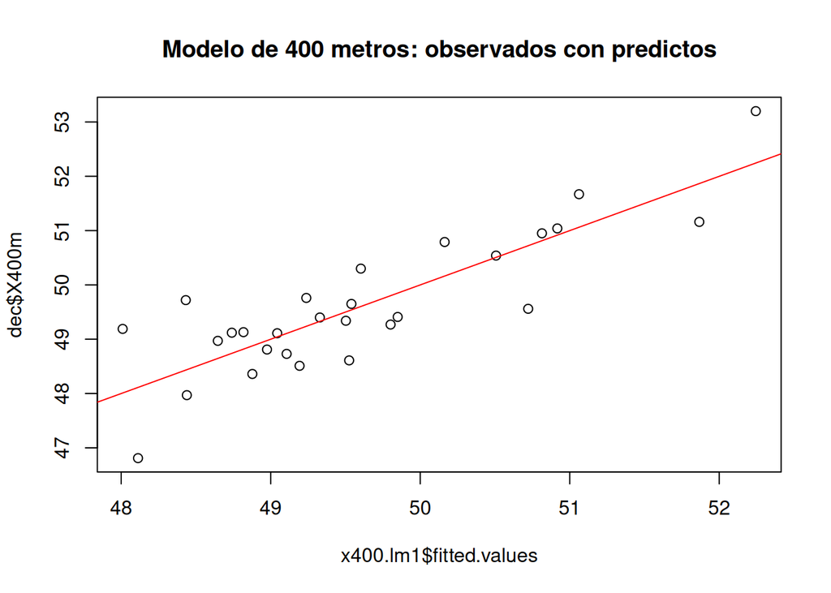

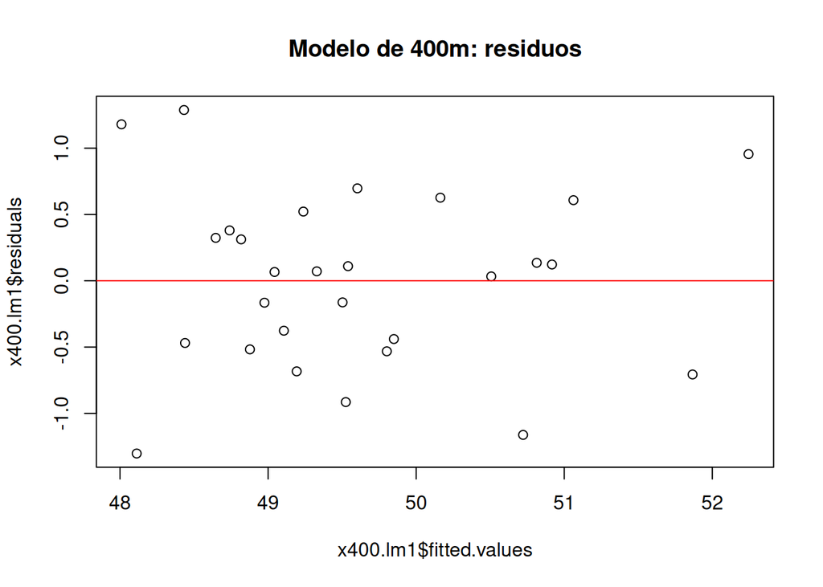

*El modelo resulta altamente significativo, explicando casi 73% de la varianza total. Igualmente son significativos los parametros, aún solo X1500m muito, signo que competencias de media longitud son relacionadas, mientras menos los X100m, que quizás requieren una calidad atlética diferente. Los gráficos son equilibrados y no aparencen unidades alejadas o muy distintas de las demás.*

*### Modelar Pole.vault*

*Seguimos modelando Pole.vault: la función step con cualquier método solo proporciona el mismo modelo $Pole.vault \~ Long.jump + Discus + X1500m$.*

```
##
## Call:
## lm(formula = Pole.vault ~ Long.jump + Discus + X1500m, data = dec)
##
## Residuals:
##      Min       1Q   Median       3Q      Max
## -0.38693 -0.18549 -0.03698  0.17706  0.61880
##
## Coefficients:
##                           2.5 %    97.5 % Std. Error t value Pr(>|t|)
## (Intercept)  1.252838 -2.474506  4.980181   1.805972   0.694   0.4945
## Long.jump    0.358420  0.029972  0.686868   0.159139   2.252   0.0337 *
## Discus      -0.031618 -0.066049  0.002814   0.016683  -1.895   0.0702 .
## X1500m       0.008208 -0.001615  0.018032   0.004760   1.725   0.0975 .
## ---
## Signif. codes:  0 '***' 0.001 '**' 0.01 '*' 0.05 '.' 0.1 ' ' 1
##
## Residual standard error: 0.2668 on 24 degrees of freedom
## Multiple R-squared:  0.2445, Adjusted R-squared:  0.1501
## F-statistic: 2.589 on 3 and 24 DF,  p-value: 0.07638
```

```
## Anova Table (Type II tests)
##
## Response: Pole.vault
##            Sum Sq Df F value  Pr(>F)
## Long.jump 0.36105  1  5.0726 0.03373 *
## Discus    0.25567  1  3.5920 0.07017 .
## X1500m    0.21168  1  2.9740 0.09747 .
## Residuals 1.70825 24
## ---
## Signif. codes:  0 '***' 0.001 '**' 0.01 '*' 0.05 '.' 0.1 ' ' 1
```

```
##              (Intercept)     Long.jump        Discus        X1500m
## (Intercept)  3.261535644 -0.1945884301 -7.902890e-04 -6.521691e-03
## Long.jump   -0.194588430  0.0253253642 -7.769968e-04  1.623536e-04
## Discus      -0.000790289 -0.0007769968  2.783093e-04 -2.130944e-05
## X1500m      -0.006521691  0.0001623536 -2.130944e-05  2.265423e-05
```

*El modelo no es muy significativo, ya que la probabilidad asociada es de 7.6% y el $R^2$ se resulta de poco inferior a 25%. Además, de los tres regresores propuestos, solo Long.jump resulta debolmente relevante. Por consecuencia, intentamos un modelo de Long.jump y otro regresor y uno solo y comparamos-los:*

```r
x800.lm2            <- lm(Pole.vault ~ Long.jump + Discus, data=dec)
anova(x800.lm2,x800.lm1)
```

```
## Analysis of Variance Table
##
## Model 1: Pole.vault ~ Long.jump + Discus
## Model 2: Pole.vault ~ Long.jump + Discus + X1500m
##   Res.Df    RSS Df Sum of Sq     F  Pr(>F)
## 1     25 1.9199
## 2     24 1.7083  1   0.21168 2.974 0.09747 .
## ---
## Signif. codes:  0 '***' 0.001 '**' 0.01 '*' 0.05 '.' 0.1 ' ' 1
```

```r
x800.lm3            <- lm(Pole.vault ~ Long.jump, data=dec)
anova(x800.lm3,x800.lm1)
```

```
## Analysis of Variance Table
##
## Model 1: Pole.vault ~ Long.jump
## Model 2: Pole.vault ~ Long.jump + Discus + X1500m
##   Res.Df    RSS Df Sum of Sq      F  Pr(>F)
## 1     26 2.0773
## 2     24 1.7083  2   0.36906 2.5926 0.09563 .
## ---
## Signif. codes:  0 '***' 0.001 '**' 0.01 '*' 0.05 '.' 0.1 ' ' 1
```

*La comparación mostra una diferencia un poco arriba del umbral, así que vamos profundizando el examen, comparando los resultados.*

```r
sum.lm(x800.lm2)
```

```
##
## Call:
## lm(formula = Pole.vault ~ Long.jump + Discus, data = dec)
##
## Residuals:
##      Min       1Q   Median       3Q      Max
## -0.41229 -0.24108 -0.00436  0.14867  0.69517
##
## Coefficients:
##                         2.5 %   97.5 % Std. Error t value Pr(>|t|)
## (Intercept)  3.61580  1.09898  6.13262    1.22203   2.959  0.00666 **
## Long.jump    0.29960 -0.03294  0.63213    0.16146   1.856  0.07535 .
## Discus      -0.02390 -0.05828  0.01048    0.01669  -1.432  0.16466
## ---
## Signif. codes:  0 '***' 0.001 '**' 0.01 '*' 0.05 '.' 0.1 ' ' 1
##
## Residual standard error: 0.2771 on 25 degrees of freedom
## Multiple R-squared:  0.1509, Adjusted R-squared:  0.08294
## F-statistic: 2.221 on 2 and 25 DF,  p-value: 0.1295
```

```r
sum.lm(x800.lm3)
```

```
##
## Call:
## lm(formula = Pole.vault ~ Long.jump, data = dec)
##
## Residuals:
##      Min       1Q   Median       3Q      Max
## -0.42194 -0.20056  0.00757  0.17202  0.64663
##
## Coefficients:
##                         2.5 %   97.5 % Std. Error t value Pr(>|t|)
## (Intercept)  2.97506  0.59099  5.35913    1.15983   2.565   0.0164 *
## Long.jump    0.24183 -0.08595  0.56961    0.15946   1.517   0.1414
## ---
## Signif. codes:  0 '***' 0.001 '**' 0.01 '*' 0.05 '.' 0.1 ' ' 1
##
## Residual standard error: 0.2827 on 26 degrees of freedom
## Multiple R-squared:  0.08127,    Adjusted R-squared:  0.04593
## F-statistic:   2.3 on 1 and 26 DF,  p-value: 0.1414
```

*Inútil seguir profundizando: la calidad del modelo sigue baixando, ni mejora la significatividad de Long.jump. Por tanto no se piensa que no sea el caso de modelar Pole.vault con otras especialidades.*

## 12 guardar los archivos

.Rmd y .html y enviar-los a sergio@camiz.it dentro del 10 de Mayo.